# EDA on 'Netfix Titles Data'

The goal of this project is to analyze the trends in content by country, year, genre and type.

Dataset: Netflix Shows (Kaggle): https://www.kaggle.com/datasets/infamouscoder/dataset-netflix-shows

**Load Dataset**

```python
import pandas as pd

df=pd.read_csv('Netflix_Show_Dataset.zip', compression='zip')
df
```

|  | show_id | type | title | director | cast | country | date_added | release_year | rating | duration | listed_in | description |
| --- | --- | --- | --- | --- | --- | --- | --- | --- | --- | --- | --- | --- |
| 0 | s1 | Movie | Dick Johnson Is Dead | Kirsten Johnson | NaN | United States | September 25, 2021 | 2020 | PG-13 | 90 min | Documentaries | As her father nears the end of his life, filmm... |
| 1 | s2 | TV Show | Blood & Water | NaN | Ama Qamata, Khosi Ngema, Gail Mabalane, Thaban... | South Africa | September 24, 2021 | 2021 | TV-MA | 2 Seasons | International TV Shows, TV Dramas, TV Mysteries | After crossing paths at a party, a Cape Town t... |
| 2 | s3 | TV Show | Ganglands | Julien Leclercq | Sami Bouajila, Tracy Gotoas, Samuel Jouy, Nabi... | NaN | September 24, 2021 | 2021 | TV-MA | 1 Season | Crime TV Shows, International TV Shows, TV Act... | To protect his family from a powerful drug lor... |
| 3 | s4 | TV Show | Jailbirds New Orleans | NaN | NaN | NaN | September 24, 2021 | 2021 | TV-MA | 1 Season | Docuseries, Reality TV | Feuds, flirtations and toilet talk go down amo... |
| 4 | s5 | TV Show | Kota Factory | NaN | Mayur More, Jitendra Kumar, Ranjan Raj, Alam K... | India | September 24, 2021 | 2021 | TV-MA | 2 Seasons | International TV Shows, Romantic TV Shows, TV ... | In a city of coaching centers known to train I... |
| ... | ... | ... | ... | ... | ... | ... | ... | ... | ... | ... | ... | ... |
| 8802 | s8803 | Movie | Zodiac | David Fincher | Mark Ruffalo, Jake Gyllenhaal, Robert Downey J... | United States | November 20, 2019 | 2007 | R | 158 min | Cult Movies, Dramas, Thrillers | A political cartoonist, a crime reporter and a... |
| 8803 | s8804 | TV Show | Zombie Dumb | NaN | NaN | NaN | July 1, 2019 | 2018 | TV-Y7 | 2 Seasons | Kids' TV, Korean TV Shows, TV Comedies | While living alone in a spooky town, a young g... |
| 8804 | s8805 | Movie | Zombieland | Ruben Fleischer | Jesse Eisenberg, Woody Harrelson, Emma Stone, ... | United States | November 1, 2019 | 2009 | R | 88 min | Comedies, Horror Movies | Looking to survive in a world taken over by zo... |
| 8805 | s8806 | Movie | Zoom | Peter Hewitt | Tim Allen, Courteney Cox, Chevy Chase, Kate Ma... | United States | January 11, 2020 | 2006 | PG | 88 min | Children & Family Movies, Comedies | Dragged from civilian life, a former superhero... |
| 8806 | s8807 | Movie | Zubaan | Mozez Singh | Vicky Kaushal, Sarah-Jane Dias, Raaghav Chanan... | India | March 2, 2019 | 2015 | TV-14 | 111 min | Dramas, International Movies, Music & Musicals | A scrappy but poor boy worms his way into a ty... |

8807 rows × 12 columns

**Missing Values Check**

```python
df.info()
```

```
<class 'pandas.core.frame.DataFrame'>
RangeIndex: 8807 entries, 0 to 8806
Data columns (total 12 columns):
 #   Column        Non-Null Count  Dtype
---  ------        --------------  -----
 0   show_id       8807 non-null   object
 1   type          8807 non-null   object
 2   title         8807 non-null   object
 3   director      6173 non-null   object
 4   cast          7982 non-null   object
 5   country       7976 non-null   object
 6   date_added    8797 non-null   object
 7   release_year  8807 non-null   int64
 8   rating        8803 non-null   object
 9   duration      8804 non-null   object
 10  listed_in     8807 non-null   object
 11  description   8807 non-null   object
dtypes: int64(1), object(11)
memory usage: 825.8+ KB
```

```python
df.isnull().sum()
```

```
show_id            0
type               0
title              0
director        2634
cast             825
country          831
date_added        10
release_year       0
rating             4
duration           3
listed_in          0
description        0
dtype: int64
```

**Data Statistics Quick Check**

```python
#only numerical values
df.describe()
```

|  | release_year |
| --- | --- |
| count | 8807.000000 |
| mean | 2014.180198 |
| std | 8.819312 |
| min | 1925.000000 |
| 25% | 2013.000000 |
| 50% | 2017.000000 |
| 75% | 2019.000000 |
| max | 2021.000000 |

```python
# all data included numerical & categorical
df.describe(include='all').T
```

|  | count | unique | top | freq | mean | std | min | 25% | 50% | 75% | max |
| --- | --- | --- | --- | --- | --- | --- | --- | --- | --- | --- | --- |
| show_id | 8807 | 8807 | s8807 | 1 | NaN | NaN | NaN | NaN | NaN | NaN | NaN |
| type | 8807 | 2 | Movie | 6131 | NaN | NaN | NaN | NaN | NaN | NaN | NaN |
| title | 8807 | 8807 | Zubaan | 1 | NaN | NaN | NaN | NaN | NaN | NaN | NaN |
| director | 6173 | 4528 | Rajiv Chilaka | 19 | NaN | NaN | NaN | NaN | NaN | NaN | NaN |
| cast | 7982 | 7692 | David Attenborough | 19 | NaN | NaN | NaN | NaN | NaN | NaN | NaN |
| country | 7976 | 748 | United States | 2818 | NaN | NaN | NaN | NaN | NaN | NaN | NaN |
| date_added | 8797 | 1767 | January 1, 2020 | 109 | NaN | NaN | NaN | NaN | NaN | NaN | NaN |
| release_year | 8807.0 | NaN | NaN | NaN | 2014.180198 | 8.819312 | 1925.0 | 2013.0 | 2017.0 | 2019.0 | 2021.0 |
| rating | 8803 | 17 | TV-MA | 3207 | NaN | NaN | NaN | NaN | NaN | NaN | NaN |
| duration | 8804 | 220 | 1 Season | 1793 | NaN | NaN | NaN | NaN | NaN | NaN | NaN |
| listed_in | 8807 | 514 | Dramas, International Movies | 362 | NaN | NaN | NaN | NaN | NaN | NaN | NaN |
| description | 8807 | 8775 | Paranormal activity at a lush, abandoned prope... | 4 | NaN | NaN | NaN | NaN | NaN | NaN | NaN |

### Data Cleaning

Let's handle the missing values from the previous missing data observetion.

**1. Director, Country & Cast**

This columns contain the most NaN values, but instead of deleting them, handle this missing values with 'Unknown' replacement.

```python
columns_to_fill= ['director', 'cast', 'country']

df[columns_to_fill]=df[columns_to_fill].fillna('Unknown')
```

**2. Rating**

For the rating column we will fill the missing values with "Not Rated" values.

```python
df['rating']=df['rating'].fillna('Not Rated')
```

**3. Date_added**

Date_added column has only 10 missing values so we can just drop them without making any big noise or change in our dataset.

```python
df['date_added']=pd.to_datetime(df['date_added'], errors='coerce')
df=df.dropna(subset=['date_added'])
```

**4. Listed_in**

We split the genre (categories) just in case if one gendre contains multiple categories.

```python
df['genre']=df['listed_in'].apply(lambda x: x.split(',')[0])
```

**5. Duration**

```python
df=df.dropna(subset=['duration'])
```

```python
df.isnull().sum()
```

```
show_id         0
type            0
title           0
director        0
cast            0
country         0
date_added      0
release_year    0
rating          0
duration        0
listed_in       0
description     0
genre           0
dtype: int64
```

```python
df.shape
```

```
(8706, 13)
```

### Data Manipulation

Convert our 'date_added' for trend investigation.

```python
df['date_added'] = pd.to_datetime(df['date_added'], format='%B %d, %Y', errors='coerce')
```

```python
# create year column
```

```python
df['year_added'] = df['date_added'].dt.year
```

### EDA on Netflix Dataset

#### 1. Analysis of Type and its trends over time

**Count Movies and TV Shows**

```python
type_counts=df['type'].value_counts()
type_counts
```

```
type
Movie      6128
TV Show    2578
Name: count, dtype: int64
```

#### Visual

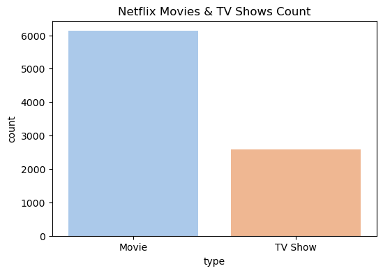

```python
import matplotlib.pyplot as plt
import seaborn as sns

plt.figure(figsize=(6,4))
sns.countplot(data=df, x='type', palette='pastel')
plt.title('Netflix Movies & TV Shows Count')
plt.show()
```

This bar chart compares the total number of Movies and TV Shows available on Netflix Dataset. Typically, according to the findings movies are displayed as the dominant of the catalog, but we know that TV shows also have been growing in recent years. This helps highlight the balance between short-form and long-form content.

**Trend releases Over Years + by release year** (original release year)

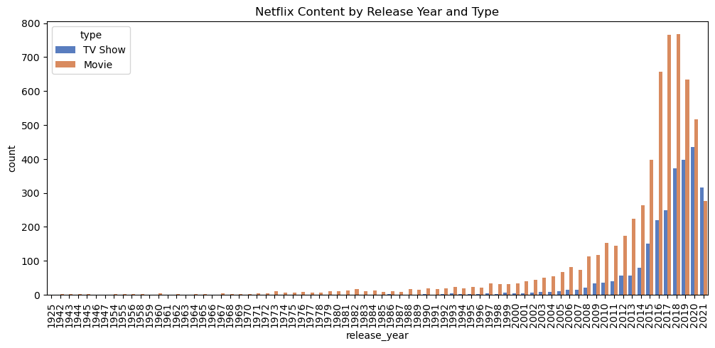

```python
plt.figure(figsize=(12,5))
sns.countplot(data=df, x='release_year', hue='type', palette='muted')
plt.xticks(rotation=90)
plt.title('Netflix Content by Release Year and Type')
plt.show()
```

**Trend releases Over Years + by year released on Netfix** (Netflix release year)

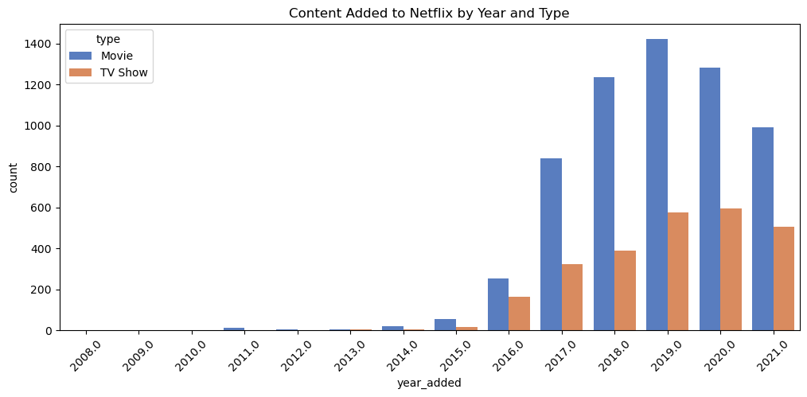

```python
plt.figure(figsize=(12,5))
sns.countplot(data=df, x='year_added', hue='type', palette='muted')
plt.xticks(rotation=45)
plt.title('Content Added to Netflix by Year and Type')
plt.show()
```

#### 2. Analysis by Country

**Top 10 most Producing Countries (on Movies, TV shows)**

```
country
United States     2775
India              971
Unknown            827
United Kingdom     403
Japan              241
South Korea        195
Canada             173
Spain              141
France             122
Mexico             110
Name: count, dtype: int64
```

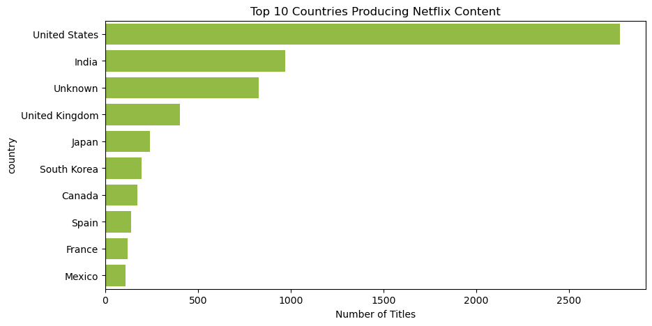

```python
top_countries = df['country'].value_counts().head(10)
print(top_countries)

# Plot
plt.figure(figsize=(10,5))
sns.barplot(x=top_countries.values, y=top_countries.index, color='yellowgreen')
plt.title('Top 10 Countries Producing Netflix Content')
plt.xlabel('Number of Titles')
plt.show()
```

**Trends on Top Producing Countries Over Time**

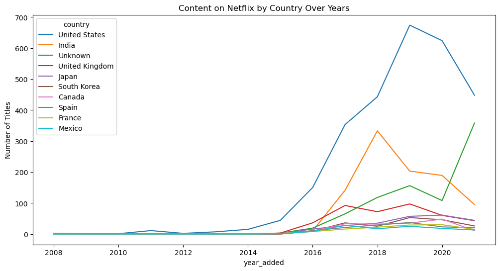

```python
country_year = df.groupby(['year_added', 'country']).size().unstack(fill_value=0)
country_year[top_countries.index].plot(figsize=(12,6))
plt.title('Content on Netflix by Country Over Years')
plt.ylabel('Number of Titles')
plt.show()
```

This bar chart and line chart highlight which countries contribute the most titles to Netflix and the year they start to contribute. The United States usually dominates, but countries like India, the UK, Japan, and South Korea are important players, especially in TV shows.

#### 3. Analysis by Genre

**3.1 Popular Genres**

```
genre
Dramas                      1600
Comedies                    1210
Action & Adventure           859
Documentaries                829
International TV Shows       761
Children & Family Movies     605
Crime TV Shows               391
Kids' TV                     373
Stand-Up Comedy              334
Horror Movies                275
Name: count, dtype: int64
```

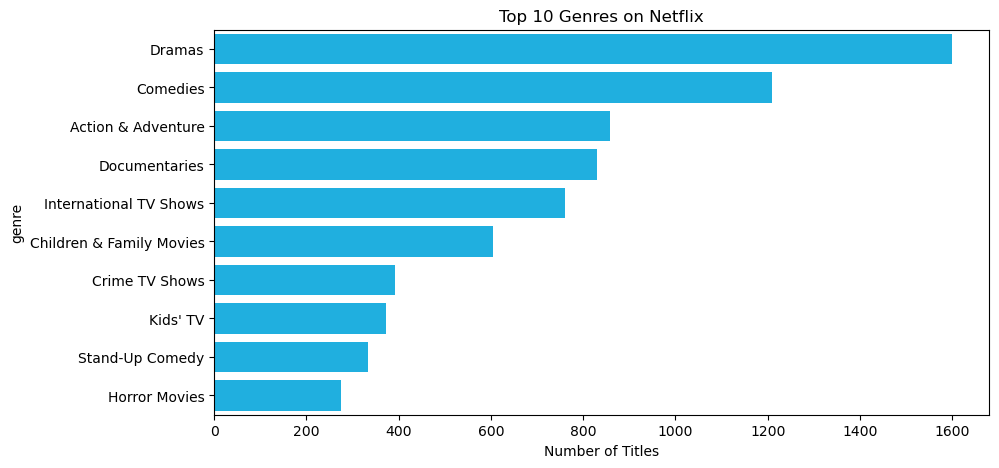

```python
genre_counts = df['genre'].value_counts().head(10)
print(genre_counts)

# Plot
plt.figure(figsize=(10,5))
sns.barplot(x=genre_counts.values, y=genre_counts.index, color='deepskyblue')
plt.title('Top 10 Genres on Netflix')
plt.xlabel('Number of Titles')
plt.show()
```

**3.2 Genre Over Time**

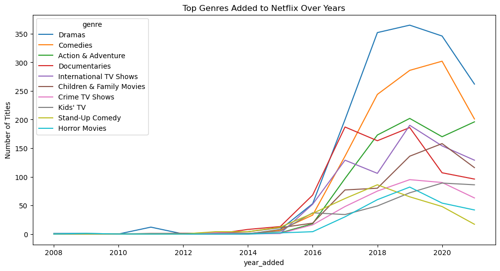

```python
top_genres=df['genre'].value_counts().head(10).index

genre_year = df.groupby(['year_added', 'genre']).size().unstack(fill_value=0)

genre_year[top_genres].plot(figsize=(12,6))
plt.title('Top Genres Added to Netflix Over Years')
plt.ylabel('Number of Titles')
plt.show()
```

These visualizations show the most popular genres in the dataset and how their populatiy changes over time. Genres such as Dramas, Comedies, and Documentaries are often at the top peaks. This helps us understand what types of content are most frequently produced and available for Netflix audiences.

#### 4. Analysis of Rating Distribution

**4.1 Rating Distribution**

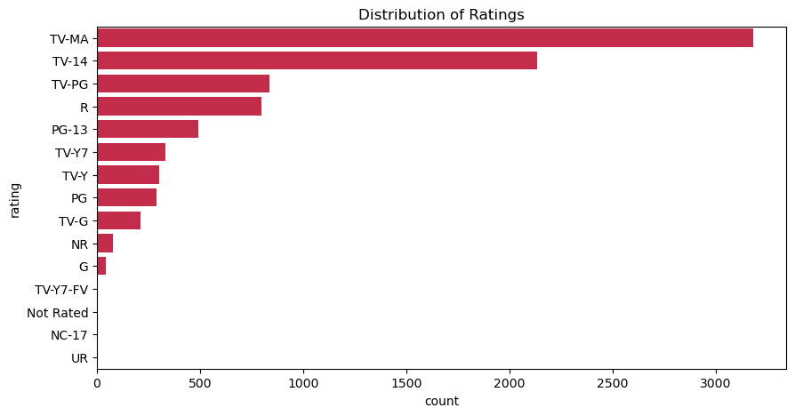

```python
plt.figure(figsize=(10,5))
sns.countplot(data=df, y='rating', order=df['rating'].value_counts().index, color='crimson')
plt.title('Distribution of Ratings')
plt.show()
```

**4.2 Duration Analysis on Type**

```python
# Create duration_int column for movies only
df['duration_int'] = df['duration'].str.extract('(\d+)')
df['duration_int'] = pd.to_numeric(df['duration_int'], errors='coerce')
```

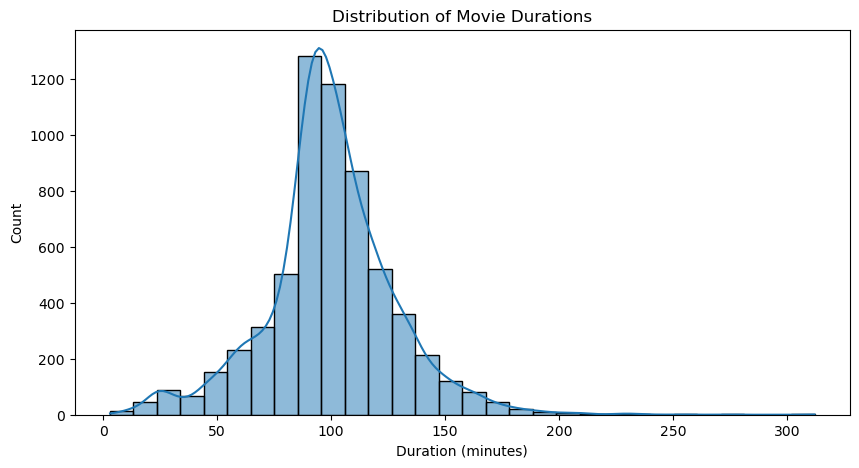

```python
plt.figure(figsize=(10,5))
sns.histplot(df[df['type']=='Movie']['duration_int'].dropna(), bins=30, kde=True)
plt.title('Distribution of Movie Durations')
plt.xlabel('Duration (minutes)')
plt.show()
```

### Dashboard

```
Netflix Dataset KPIs
Total Titles: 8709
Movies: 6131
TV Shows: 2578
Countries: 746
Unique Genres: 36
```

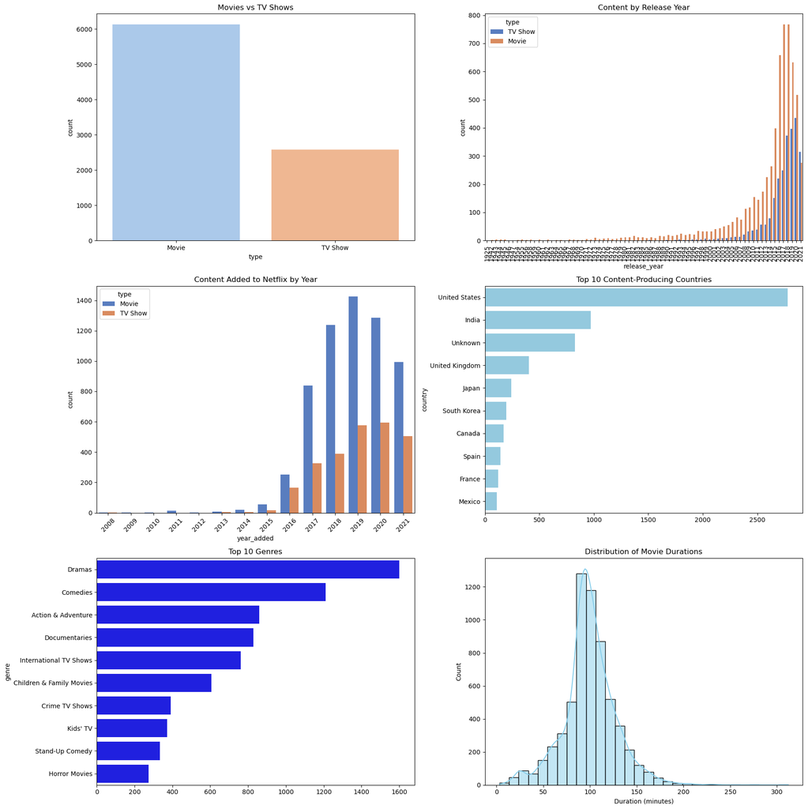

```python
import pandas as pd
import matplotlib.pyplot as plt
import seaborn as sns

# Load dataset
df = pd.read_csv('Netflix_Show_Dataset.zip', compression='zip')

# Cleaning
df['date_added'] = pd.to_datetime(df['date_added'], errors='coerce')
df = df.dropna(subset=['date_added'])
df[['director','cast','country']] = df[['director','cast','country']].fillna('Unknown')
df['rating'] = df['rating'].fillna('Not Rated')
df['genre'] = df['listed_in'].apply(lambda x: x.split(',')[0])
df['year_added'] = df['date_added'].dt.year
df['duration_int'] = pd.to_numeric(df['duration'].str.extract('(\d+)')[0], errors='coerce')

# KPIs
total_titles = len(df)
total_movies = df[df['type']=='Movie'].shape[0]
total_shows = df[df['type']=='TV Show'].shape[0]
unique_countries = df['country'].nunique()
unique_genres = df['genre'].nunique()

print("Netflix Dataset KPIs")
print(f"Total Titles: {total_titles}")
print(f"Movies: {total_movies}")
print(f"TV Shows: {total_shows}")
print(f"Countries: {unique_countries}")
print(f"Unique Genres: {unique_genres}")

# Dashboard Layout
plt.figure(figsize=(18,18))

# 1. Movies vs TV Shows
plt.subplot(3,2,1)
sns.countplot(data=df, x='type', palette='pastel')
plt.title("Movies vs TV Shows")

# 2. Content by Release Year
plt.subplot(3,2,2)
sns.countplot(data=df, x='release_year', hue='type', palette='muted')
plt.xticks(rotation=90)
plt.title("Content by Release Year")

# 3. Content by Netflix Added Year
plt.subplot(3,2,3)
sns.countplot(data=df, x='year_added', hue='type', palette='muted')
plt.xticks(rotation=45)
plt.title("Content Added to Netflix by Year")

# 4. Top 10 Countries
plt.subplot(3,2,4)
top_countries = df['country'].value_counts().head(10)
sns.barplot(x=top_countries.values, y=top_countries.index, color='skyblue')
plt.title("Top 10 Content-Producing Countries")

# 5. Top 10 Genres
plt.subplot(3,2,5)
top_genres = df['genre'].value_counts().head(10)
sns.barplot(x=top_genres.values, y=top_genres.index, color='blue')
plt.title("Top 10 Genres")

# 6. Movie Duration Distribution
plt.subplot(3,2,6)
sns.histplot(df[df['type']=='Movie']['duration_int'].dropna(), bins=30, kde=True, color='skyblue')
plt.title("Distribution of Movie Durations")
plt.xlabel("Duration (minutes)")

plt.tight_layout()
plt.show()
```